# Lab 1

Haley Jeppson, Ashish Jain, Vinny Paris

January 19, 2017

## Question 1: Building a Book

#### VINNY’s problems:

While trying to compile H. Wickham’s Advanced R book I run into the following issue:

`grep: Inconsolata.log: No such file or directory mktextfm: mf-nowin -progname=mf \mode:=ljfour; mag:=1; nonstopmode;` `input Inconsolata' failed to make Inconsolata.tfm.`

I am using a mac and I believe that the problem is a font does not naturally exist on my computer. Certain pieces of the book were created though (including the dedication and copyright section). I have downloaded the Inconsolata file but am stuck figuring out how to move it to the Font directory in my library. So my question is two fold: 1) Am I on the right track? 2) How do I move a file around on a mac? Thank you!

#### Ashish’s Problems and Solutions:

I also faced the same problem while knitting the H. Wickham’s Advanced R book. The book is using the “Inconsolata” font which is not a default font in mac. So in order to debug it, I googled it.

**“Whenever in trouble use GOOGLE”**

While searching through the internet we found the solution. First, we downloaded the Inconsolota font from [link](https://cooltext.com/Download-Font-Inconsolata). After that, we followed [these](http://superuser.com/questions/56787/how-to-install-and-find-fonts-for-mac-os-x) instructions and copied the font file into the following folders.

- /Library/Fonts/
- /Users/username/Library/Fonts

Thank you Haley and Vinny for your help!!

#### Haley’s Problems and Solutions:

I encountered the same issues as Vinny and Ashish did when attempting to knit Advanced R. Ashish was able to troubleshoot and realize that we were not able to get the book to knit because we were all missing the “Inconsolata” font. I was fortunate to not be a mac user at this moment. In order to install the font on a Ubuntu platform, I simply had to run the code `sudo apt-get install fonts-inconsolata` in the terminal (thanks stackoverflow!). After doing so, I was able to compile the pdf and discover that the last word on page 21 is “May”.

## Question 2: Weather Stations

#### Retrieving the Data

The function `tmax` takes the argument `stationid` in the form of six digits, reads in the corresponding file, and cleans the tibble before returning it.

```r
library(tidyverse)

tmax <- function(stationid){
  # paste together file name
  station <- paste("https://raw.githubusercontent.com/haleyjeppson/Data-Technologies/master/Lab1/ushcn.v2.5.5.20170118/USH00", stationid, ".raw.tmax", sep="")
  # read in the file
  temps <- read_fwf(station,
                   col_positions=  fwf_positions(
                     start=c( 1,13, rep(16+9*0:11, each=4) + c(1,7,8,9)),
                     end  =c(11,16, rep(16+9*0:11, each=4) + c(6,7,8,9))))

  # rename the column names
names(temps) <- c("Station", "Year",
                 paste0(rep(c("Value","DMflag", "QCflag", "DSflag"), 12),
                        rep(1:12, each=4)))

# Now to tidy the data a little
# First, gather all columns that start with "Value" and create a new column for Month based on number that follows "value"
temps <- temps %>%
  gather(key="Month", value="Temp_Max", starts_with("Value"))
temps$Month <- as.numeric(gsub("Value", "", temps$Month))
# replace the -9999 temperature values with NAs
temps$Temp_Max <- replace(temps$Temp_Max,
                          temps$Temp_Max == -9999, NA)
# Reformat temps and create a variable for year and month.
temps$Temp_Max <- temps$Temp_Max/100
temps$YearMonth <- temps$Year+temps$Month/12

# Return cleaned tibble
temps
}
```

Using the `tmax` function just created, we can retrieve the data from any station using the six digit station ID. Here we retrieve the data from station 041758 located in Chula Vista, California.

```r
vista <- tmax("041758")

head(vista)
```

```
## # A tibble: 6 × 41
##       Station  Year DMflag1 QCflag1 DSflag1 DMflag2 QCflag2 DSflag2
##         <chr> <int>   <chr>   <chr>   <chr>   <chr>   <chr>   <int>
## 1 USH00041758  1918    <NA>    <NA>    <NA>    <NA>    <NA>      NA
## 2 USH00041758  1919    <NA>    <NA>    <NA>    <NA>    <NA>      NA
## 3 USH00041758  1920    <NA>    <NA>    <NA>    <NA>    <NA>      NA
## 4 USH00041758  1921    <NA>    <NA>    <NA>    <NA>    <NA>      NA
## 5 USH00041758  1922    <NA>    <NA>    <NA>    <NA>    <NA>      NA
## 6 USH00041758  1923    <NA>    <NA>    <NA>    <NA>    <NA>      NA
## # ... with 33 more variables: DMflag3 <chr>, QCflag3 <chr>, DSflag3 <int>,
## #   DMflag4 <chr>, QCflag4 <chr>, DSflag4 <int>, DMflag5 <chr>,
## #   QCflag5 <chr>, DSflag5 <int>, DMflag6 <chr>, QCflag6 <chr>,
## #   DSflag6 <chr>, DMflag7 <chr>, QCflag7 <chr>, DSflag7 <chr>,
## #   DMflag8 <chr>, QCflag8 <chr>, DSflag8 <chr>, DMflag9 <chr>,
## #   QCflag9 <chr>, DSflag9 <int>, DMflag10 <chr>, QCflag10 <chr>,
## #   DSflag10 <int>, DMflag11 <chr>, QCflag11 <chr>, DSflag11 <chr>,
## #   DMflag12 <chr>, QCflag12 <chr>, DSflag12 <int>, Month <dbl>,
## #   Temp_Max <dbl>, YearMonth <dbl>
```

#### Visualizing the temperature records over time

The plots below use the maximum temperatures recorded at station 041758 in Chula Vista, California between the years 1918 and 2016.

This first graphic plots the maximum temperature recorded for each month throughout the years.

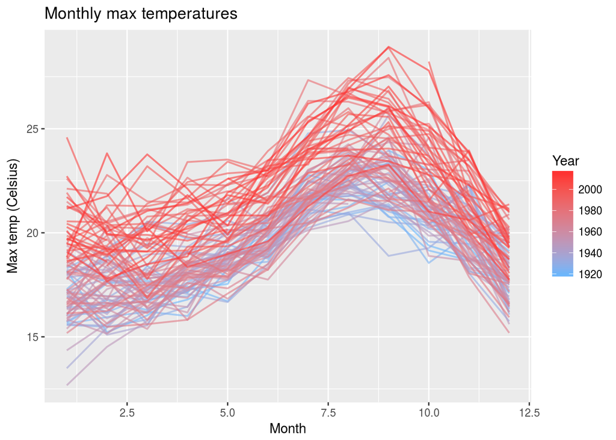

```r
vista %>% ggplot(aes(x = Month, Temp_Max, color= Year)) +
  geom_path(aes(group= Year), size=.7, alpha=.6) +
  scale_color_gradient(low="steelblue1", high="firebrick1") +
  labs(y="Max temp (Celsius)", title = "Monthly max temperatures")
```

In this plot we can see a clear trend of warmer temperatures in the more recent years for every month of the year.

This next plot makes the trend seen in the first plot a little more clear by removing the seasonal trends. Here we have taken the mean maximum temperature for each year and plotted it.

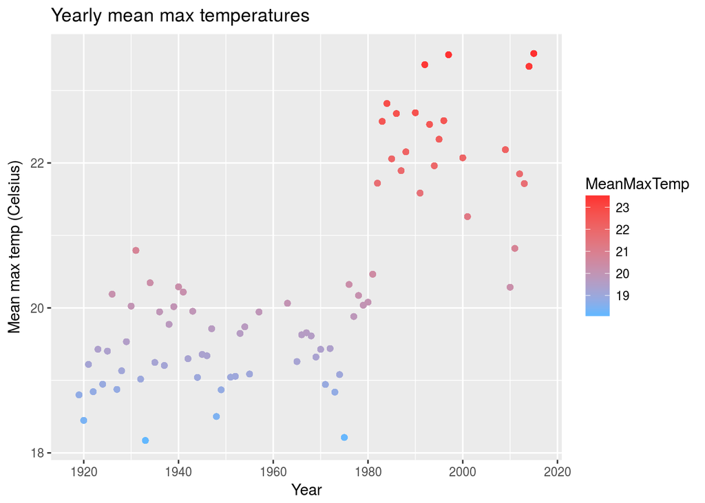

```r
vista %>%  group_by(Year) %>%
  mutate(MeanMaxTemp = mean(Temp_Max)) %>%
  ggplot(aes(x=Year, MeanMaxTemp)) +
  geom_point(aes(color=MeanMaxTemp)) +
  labs(y="Mean max temp (Celsius)", title = "Yearly mean max temperatures") +
  scale_color_gradient(low="steelblue1", high="firebrick1")
```

This plot uncovers what before appeared as a trend now looks like a breakpoint around 1980. It appears as though the yearly mean maximum temperature was much cooler in the years prior to 1980 than most of the years after 1980. This begs the question: What happened in 1980?